# Project: Investigate TMBd movie data

- Introduction
- Data Wrangling
- Exploratory Data Analysis
- Conclusions

## Introduction

The dataset to be analyzed here is collected from 'The Movie Database (TMDb)', already partially cleaned from original data on [Kaggle](https://www.kaggle.com/tmdb/tmdb-movie-metadata/home), it contains information about 10,000 movies such as user ratings and budget/revenue.  
The following questions about this dataset are raised here, with respect to the development trend of film industry and the correlation between financial performances, user ratings, and possible affecting factors.

### Questions:

1. Is there a high rate of financial failures or success?
2. Does the film industry become more and more profitable on the average over years?
3. How do the viewer's ratings of movies change over years?
4. Which genres are most popular?
5. Do comercially successful movies always have higher ratings?
6. What kinds of properties are associated with movies that have high revenues?

```python
#  import statements for all of the packages to be used
import pandas as pd
import numpy as np
import matplotlib.pyplot as plt
import matplotlib as mpl
import seaborn as sns
% matplotlib inline
```

## Data Wrangling

### General Properties

Load the data, and check for cleanliness, in order to decide what to trim for analysis later.

```python
# Load the data and print out a few lines.
Location = 'dataset/tmdb-movies.csv'
df = pd.read_csv(Location, parse_dates=['release_date'], dayfirst=True)
df.head(1)
```

|  | id | imdb_id | popularity | budget | revenue | original_title | cast | homepage | director | tagline | ... | overview | runtime | genres | production_companies | release_date | vote_count | vote_average | release_year | budget_adj | revenue_adj |
| --- | --- | --- | --- | --- | --- | --- | --- | --- | --- | --- | --- | --- | --- | --- | --- | --- | --- | --- | --- | --- | --- |
| 0 | 135397 | tt0369610 | 32.985763 | 150000000 | 1513528810 | Jurassic World | Chris Pratt\|Bryce Dallas Howard\|Irrfan Khan\|Vi... | http://www.jurassicworld.com/ | Colin Trevorrow | The park is open. | ... | Twenty-two years after the events of Jurassic ... | 124 | Action\|Adventure\|Science Fiction\|Thriller | Universal Studios\|Amblin Entertainment\|Legenda... | 2015-09-06 | 5562 | 6.5 | 2015 | 1.379999e+08 | 1.392446e+09 |

1 rows × 21 columns

```python
#  Inspect data types and look for instances of missing or possibly errant data.
df.info()
```

```
<class 'pandas.core.frame.DataFrame'>
RangeIndex: 10866 entries, 0 to 10865
Data columns (total 21 columns):
id                      10866 non-null int64
imdb_id                 10856 non-null object
popularity              10866 non-null float64
budget                  10866 non-null int64
revenue                 10866 non-null int64
original_title          10866 non-null object
cast                    10790 non-null object
homepage                2936 non-null object
director                10822 non-null object
tagline                 8042 non-null object
keywords                9373 non-null object
overview                10862 non-null object
runtime                 10866 non-null int64
genres                  10843 non-null object
production_companies    9836 non-null object
release_date            10866 non-null datetime64[ns]
vote_count              10866 non-null int64
vote_average            10866 non-null float64
release_year            10866 non-null int64
budget_adj              10866 non-null float64
revenue_adj             10866 non-null float64
dtypes: datetime64[ns](1), float64(4), int64(6), object(10)
memory usage: 1.7+ MB
```

- Data Problem 1: There are categorical data missing in column **cast**, **director**, **genres**, **production_companies**.

```python
# check the statistics of numerical data to see if there are any errors
df[['budget', 'revenue', 'budget_adj', 'revenue_adj', 'runtime', 'release_year', 'vote_count', 'vote_average']].describe()
```

|  | budget | revenue | budget_adj | revenue_adj | runtime | release_year | vote_count | vote_average |
| --- | --- | --- | --- | --- | --- | --- | --- | --- |
| count | 1.086600e+04 | 1.086600e+04 | 1.086600e+04 | 1.086600e+04 | 10866.000000 | 10866.000000 | 10866.000000 | 10866.000000 |
| mean | 1.462570e+07 | 3.982332e+07 | 1.755104e+07 | 5.136436e+07 | 102.070863 | 2001.322658 | 217.389748 | 5.974922 |
| std | 3.091321e+07 | 1.170035e+08 | 3.430616e+07 | 1.446325e+08 | 31.381405 | 12.812941 | 575.619058 | 0.935142 |
| min | 0.000000e+00 | 0.000000e+00 | 0.000000e+00 | 0.000000e+00 | 0.000000 | 1960.000000 | 10.000000 | 1.500000 |
| 25% | 0.000000e+00 | 0.000000e+00 | 0.000000e+00 | 0.000000e+00 | 90.000000 | 1995.000000 | 17.000000 | 5.400000 |
| 50% | 0.000000e+00 | 0.000000e+00 | 0.000000e+00 | 0.000000e+00 | 99.000000 | 2006.000000 | 38.000000 | 6.000000 |
| 75% | 1.500000e+07 | 2.400000e+07 | 2.085325e+07 | 3.369710e+07 | 111.000000 | 2011.000000 | 145.750000 | 6.600000 |
| max | 4.250000e+08 | 2.781506e+09 | 4.250000e+08 | 2.827124e+09 | 900.000000 | 2015.000000 | 9767.000000 | 9.200000 |

- Data Problem 2: **Budget**, **revenue**, and **runtime** should be nonzero values.

```python
# the statistics of datetime data does not apply the same way as the numerical data above
df.release_date.describe()
```

```
count                   10866
unique                   5909
top       2009-01-01 00:00:00
freq                       28
first     1968-01-01 00:00:00
last      2067-12-27 00:00:00
Name: release_date, dtype: object
```

- Data Problem 3: Errors exist in **release_date** column, because it is inconsistent with the **release_year** column, there are illogical year values from the future in the former but not in the latter.

```python
# check inconsistent data in date/year of release
sum(df.release_date.dt.year != df.release_year)
```

```
292
```

```python
# check if there are duplicated data
sum(df.duplicated())
```

```
1
```

- There are 292 cells with wrong year values in **release_data** column, and 1 row with duplicated values.

The problems above may overlap with each other. And the data set is too large to analyze with information that maybe biased. I will combine different aspects together to see if what are necessary to be dealed with.

### Data Cleaning

For this process, the following steps will be taken:  
step 1: drop useless columns  
step 2: drop duplicates  
step 3: filter out illogical data: budget/revenue/runtime equal to zero  
step 4: correct errant data: inconsistent date/year of release  
step 5: filter out biased data: ratings of movies with too few vote counts can be strongly affected by individual opinions

```python
# step 1: drop the columns that are irrelevant for the investigation
df.drop(['imdb_id','homepage','tagline','overview','keywords'], axis=1, inplace=True)
```

```python
# step 2: drop the duplicated data
df.drop_duplicates(inplace=True)
sum(df.duplicated())
```

```
0
```

```python
# step 3: filter out the movies with budget and revenue not greater than 0
# then check the statistics of the remaining movie data
df1 = df.query('budget_adj > 0 and revenue_adj > 0 and runtime>0')
df1[['popularity','vote_count','vote_average','budget_adj','revenue_adj']].describe()
```

|  | popularity | vote_count | vote_average | budget_adj | revenue_adj |
| --- | --- | --- | --- | --- | --- |
| count | 3854.000000 | 3854.000000 | 3854.000000 | 3.854000e+03 | 3.854000e+03 |
| mean | 1.191554 | 527.720291 | 6.168163 | 4.423999e+07 | 1.370647e+08 |
| std | 1.475162 | 879.956821 | 0.794920 | 4.480925e+07 | 2.161114e+08 |
| min | 0.001117 | 10.000000 | 2.200000 | 9.693980e-01 | 2.370705e+00 |
| 25% | 0.462368 | 71.000000 | 5.700000 | 1.309053e+07 | 1.835735e+07 |
| 50% | 0.797511 | 204.000000 | 6.200000 | 3.001611e+07 | 6.173068e+07 |
| 75% | 1.368324 | 580.000000 | 6.700000 | 6.061307e+07 | 1.632577e+08 |
| max | 32.985763 | 9767.000000 | 8.400000 | 4.250000e+08 | 2.827124e+09 |

```python
# It seems the missing data in the original data frame are mostly from movies
# that are filtered out in the last step
df1.info()
```

```
<class 'pandas.core.frame.DataFrame'>
Int64Index: 3854 entries, 0 to 10848
Data columns (total 16 columns):
id                      3854 non-null int64
popularity              3854 non-null float64
budget                  3854 non-null int64
revenue                 3854 non-null int64
original_title          3854 non-null object
cast                    3850 non-null object
director                3853 non-null object
runtime                 3854 non-null int64
genres                  3854 non-null object
production_companies    3808 non-null object
release_date            3854 non-null datetime64[ns]
vote_count              3854 non-null int64
vote_average            3854 non-null float64
release_year            3854 non-null int64
budget_adj              3854 non-null float64
revenue_adj             3854 non-null float64
dtypes: datetime64[ns](1), float64(4), int64(6), object(5)
memory usage: 511.9+ KB
```

```python
# step 4: correct errant data: inconsistent date/year of release
# some are already filtered out, there are only 58 left.
mask = df1.release_date.dt.year != df1.release_year
mask.sum()
```

```
58
```

```python
# the wrong release dates are shifted 100 years forwards
df1[mask].head(1)
```

|  | id | popularity | budget | revenue | original_title | cast | director | runtime | genres | production_companies | release_date | vote_count | vote_average | release_year | budget_adj | revenue_adj |
| --- | --- | --- | --- | --- | --- | --- | --- | --- | --- | --- | --- | --- | --- | --- | --- | --- |
| 9849 | 646 | 3.170651 | 1100000 | 59600000 | Dr. No | Sean Connery\|Ursula Andress\|Joseph Wiseman\|Jac... | Terence Young | 110 | Adventure\|Action\|Thriller | Eon Productions\|Metro-Goldwyn-Mayer (MGM) | 2062-04-10 | 560 | 6.7 | 1962 | 7.929294e+06 | 4.296236e+08 |

```python
# offset the years by 100 to correct them
df1['release_date'][mask] = df1['release_date'][mask].apply(lambda x: x - pd.DateOffset(years=100))
```

```python
df1.release_date.describe()
```

```
count                    3854
unique                   2885
top       2014-12-25 00:00:00
freq                        7
first     1960-06-10 00:00:00
last      2015-12-30 00:00:00
Name: release_date, dtype: object
```

```python
# step 5: filter out biased data: ratings of movies with too few vote counts can be strongly affected by individual opinions
df1.query('vote_average == vote_average.max()')
```

|  | id | popularity | budget | revenue | original_title | cast | director | runtime | genres | production_companies | release_date | vote_count | vote_average | release_year | budget_adj | revenue_adj |
| --- | --- | --- | --- | --- | --- | --- | --- | --- | --- | --- | --- | --- | --- | --- | --- | --- |
| 4178 | 278 | 7.192039 | 25000000 | 28341469 | The Shawshank Redemption | Tim Robbins\|Morgan Freeman\|Bob Gunton\|William ... | Frank Darabont | 142 | Drama\|Crime | Castle Rock Entertainment | 1994-10-09 | 5754 | 8.4 | 1994 | 3.677779e+07 | 4.169346e+07 |
| 7948 | 24128 | 0.283191 | 1200000 | 4978922 | Stop Making Sense | David Byrne\|Tina Weymouth\|Chris Frantz\|Jerry H... | Jonathan Demme | 88 | Documentary\|Music | Talking Heads\|Arnold Stiefel Company | 1984-11-16 | 23 | 8.4 | 1984 | 2.518850e+06 | 1.045097e+07 |

- Based on the displayed data above, there are two movies with the highest rating 8.4, however one has 5754 votes, the other has only 23. Although the movie dataset has a majority of movies with votes fewer than 200, but actually movies with more votes can represent the opinion of the majority, and not biased by individuals. The statistics of df1 showed that the movie with fewest votes has only 10, however the one with most votes has over 9000. In this step the data frame df1 will be filtered once again to take out movies with less than 10% of the max. vote counts, the rest are more comparable to each other.

```python
# filtered out the movies with less than 10% of the max. vote counts
df2 = df1.query('vote_count >= 0.1*vote_count.max()')
df2.describe()
```

|  | id | popularity | budget | revenue | runtime | vote_count | vote_average | release_year | budget_adj | revenue_adj |
| --- | --- | --- | --- | --- | --- | --- | --- | --- | --- | --- |
| count | 571.000000 | 571.000000 | 5.710000e+02 | 5.710000e+02 | 571.000000 | 571.000000 | 571.000000 | 571.000000 | 5.710000e+02 | 5.710000e+02 |
| mean | 58272.845884 | 3.317367 | 8.497147e+07 | 3.600059e+08 | 119.714536 | 2175.225919 | 6.797373 | 2006.346760 | 8.919370e+07 | 4.042185e+08 |
| std | 77962.908219 | 2.759560 | 6.483269e+07 | 3.130413e+08 | 21.762049 | 1313.034927 | 0.697597 | 9.122686 | 6.357302e+07 | 3.688804e+08 |
| min | 11.000000 | 0.040858 | 4.000000e+05 | 1.270522e+06 | 76.000000 | 979.000000 | 4.400000 | 1960.000000 | 1.385334e+06 | 1.564633e+06 |
| 25% | 823.000000 | 1.876517 | 3.000000e+07 | 1.393518e+08 | 104.000000 | 1257.500000 | 6.300000 | 2003.000000 | 3.557402e+07 | 1.500093e+08 |
| 50% | 18823.000000 | 2.657014 | 7.000000e+07 | 2.744704e+08 | 117.000000 | 1735.000000 | 6.800000 | 2010.000000 | 7.829274e+07 | 2.976587e+08 |
| 75% | 82691.500000 | 3.914173 | 1.300000e+08 | 4.823505e+08 | 131.000000 | 2647.000000 | 7.300000 | 2013.000000 | 1.328451e+08 | 5.537560e+08 |
| max | 321697.000000 | 32.985763 | 3.800000e+08 | 2.781506e+09 | 201.000000 | 9767.000000 | 8.400000 | 2015.000000 | 3.683713e+08 | 2.827124e+09 |

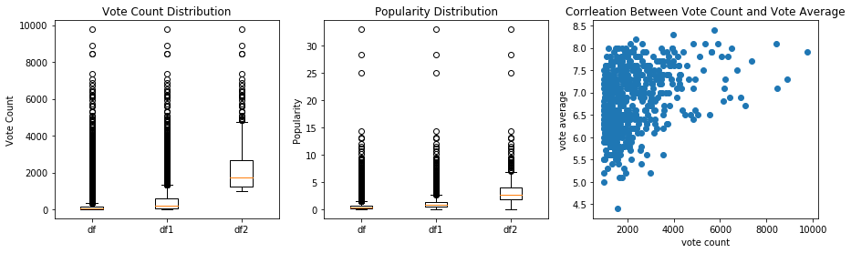

```python
# comparison between the original data set, and filtered data sets
fig, axes = plt.subplots(ncols=3, figsize=(15,4))
axes[0].boxplot((df.vote_count, df1.vote_count, df2.vote_count), labels=['df', 'df1', 'df2']);
axes[1].boxplot((df.popularity, df1.popularity, df2.popularity), labels=['df', 'df1', 'df2']);
axes[2].scatter(df2.vote_count, df2.vote_average);
axes[0].set_title('Vote Count Distribution');
axes[0].set_ylabel('Vote Count');
axes[1].set_title('Popularity Distribution');
axes[1].set_ylabel('Popularity');
axes[2].set_title('Corrleation Between Vote Count and Vote Average');
axes[2].set_xlabel('vote count');
axes[2].set_ylabel('vote average');
```

- After filtering the dataset, the **vote_count** and **popularity** data of df2 are much more evenly distributed.
- Correlation between **vote_count** and **vote_average** indicates that movies with more votes are usually the ones with higher ratings. They are interesting in the investigation and should not be considered as outliers.

## Exploratory Data Analysis

### Research Question Set 1

**Keywords:** Trend Analysis, financial performance

1. Is there a high rate of financial failures or success?
2. Does the film industry become more and more profitable on the average over years?
3. How do the viewer's ratings of movies change over years?

**Q1: Is there a high rate of financial failures or success?**  
What is an appropriate indicator for financial performance?

> "It is worth noting that a truly profitable film typically has to earn about double its production cost." (Eliashberg, Hui, & Zhang, 2006)

```python
# Let's assume the criterion for financial performance to be successfully profitableß is: revenue >= 2* budget
df1.loc[: , 'success'] = df1.loc[ : , 'revenue_adj'] >= 2*df1.loc[ : , 'budget_adj']
df1.loc[: , 'failure'] = df1.loc[ : , 'revenue_adj'] <= df1.loc[ : , 'budget_adj']
df1[['success','failure']].describe()
```

|  | success | failure |
| --- | --- | --- |
| count | 3854 | 3854 |
| unique | 2 | 2 |
| top | True | False |
| freq | 2025 | 2778 |

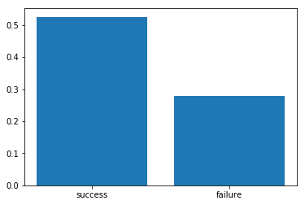

```python
success_rate = df1['success'].sum()/df1.shape[0]
failure_rate = df1['failure'].sum()/df1.shape[0]
plt.bar(['success', 'failure'], [success_rate, failure_rate]);
```

- Instead of df2, df1 is investigated here to determine the financial success/failure rate, because it contains more information about the film industry. One the other side, df2 will be used for other analysis.
- There are movies between real failure and success, they are not included here in the bar plot.

**Conclusion 1:** There are higher rate of success than failure overall.

**Q2: Does the film industry become more and more profitable on the average over years?**

```python
# The following profit factor is defined as indicator to determine if the film industry is profitable.
df2['profit_factor'] = df2.revenue_adj/df2.budget_adj
```

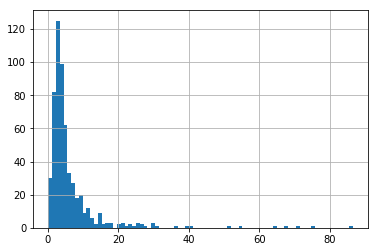

```python
# distribution of the single variable: profit factor
df2.profit_factor.hist(bins=80);
```

```python
# set the bin size to be 20 years, and divide the filtered dataset df2 into three groups
movie_bin1 = df2.query('release_year >= 1960 & release_year <= 1979')
movie_bin2 = df2.query('release_year >= 1980 & release_year <= 1999')
movie_bin3 = df2.query('release_year >= 2000 & release_year <= 2020')
labels = ['1960~1979', '1980~1999', '2000~2015']
```

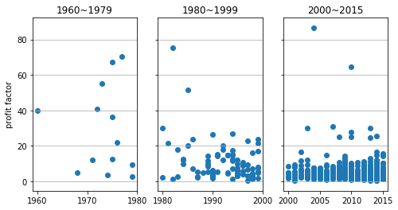

```python
# scatter plots of profit factor over years
fig, axes = plt.subplots(ncols=3, figsize=(8, 4), sharex=False, sharey=True)

axes[0].scatter(movie_bin1.release_year, movie_bin1.profit_factor);
axes[1].scatter(movie_bin2.release_year, movie_bin2.profit_factor);
axes[2].scatter(movie_bin3.release_year, movie_bin3.profit_factor);
i = 0
for ax in axes:
    ax.yaxis.grid(True)
    ax.set_title(labels[i])
    i += 1

axes[0].set_ylabel('profit factor');
```

- The number of released movies are increasing, however the percentage of highly profitable movies (with profit factor over 20) is decreasing.

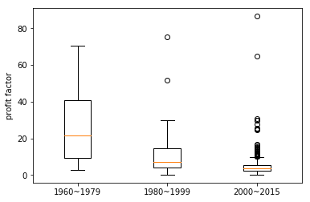

```python
# boxplot shows more details about the distribution of profit factor
fig, axis = plt.subplots();
axis.boxplot((movie_bin1.profit_factor, movie_bin2.profit_factor, movie_bin3.profit_factor),
                labels=labels);
axis.set_ylabel('profit factor');
```

**Conclusion 2:** Based on the distributions of movie profit factor above, the average profit factor is getting lower and lower.

**Q3: How do the viewer's ratings of movies change over years?**

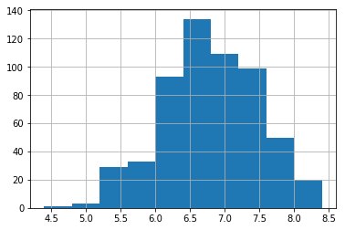

```python
# Histogram of variable vote average
df2.vote_average.hist(bins=10);
```

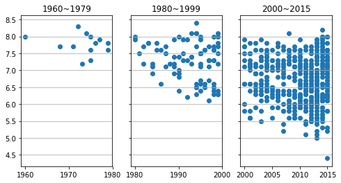

```python
# scatter plots of vote average over years
fig, axes = plt.subplots(ncols=3, figsize=(8, 4), sharey=True)

axes[0].scatter(movie_bin1.release_year, movie_bin1.vote_average);
axes[1].scatter(movie_bin2.release_year, movie_bin2.vote_average);
axes[2].scatter(movie_bin3.release_year, movie_bin3.vote_average);

i = 0
for ax in axes:
    ax.yaxis.grid(True)
    ax.set_title(labels[i])
    i += 1
```

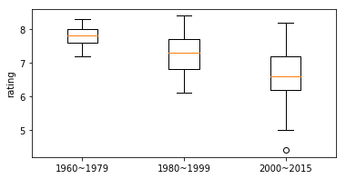

```python
labels = ['1960~1979', '1980~1999', '2000~2015']
fig, axis = plt.subplots(figsize=(6,3));
axis.boxplot((movie_bin1.vote_average,movie_bin2.vote_average,movie_bin3.vote_average), labels=labels);
axis.set_ylabel('rating');
```

**Conclusion 3:** The average ratings are getting lower and lower over years.

### Research Question Set 2

**Keywords:** rating, genre, movie properties

1. Which genres are most popular?
2. Do comercially successful movies always have higher ratings?
3. What kinds of properties are associated with movies that have high revenues?

**Q4: Which genres are most popular?** From year to year?  
To investigate which genres are most popular, two approaches are undertaken:

1. the average popularity of each genre overall is used as indicator to find out which genres are most popular in a whole, and the corresponding average ratings and revenues are used as additional information;
2. the numbers of movies produced in all genre categories over years are used as a indicator for the decision-making results of the film industry, in order to fulfill the viewers' need.

**Approach 1:** Use the average popularity of each genre overall as indicator to find out which genres are most popular in a whole, and the corresponding average ratings and revenues are used as additional information.

```python
# first, the data inside column 'genres' are categorical, most movies belong to more than one genre,
# so to access the categorical variables, the so called 'dummy matrix' or 'indicator matrix' are being introduced here.
# the original column will be divided into multiple columns, each represents a category, in the cells are 1 or 0
# using 1 to indicate that the movie belongs to this specific category. [2]
def indicator_matrix(df, col):
    col_iter = (set(x.split('|')) for x in col)
    categories = sorted(set.union(*col_iter))
    indicators = pd.DataFrame(np.zeros((len(df), len(categories))), columns = categories)
    for i, gen in enumerate(col):
        indicators.loc[i,gen.split('|')]=1
    return indicators
```

```python
# extract the columns that contain categorical variables from df2, and some other informations which can describe the movies' performance
# to define the new data frame as df3
df3 = df2[['id','popularity','vote_average','revenue_adj','release_year','director','cast','genres','production_companies']]
df3.set_index(np.arange(df3.shape[0]), inplace=True)
```

```python
# generate the indicator matrix for 'genres'
indicator_genres = indicator_matrix(df3, df3.genres)
indicator_genres.head(1)
```

|  | Action | Adventure | Animation | Comedy | Crime | Drama | Family | Fantasy | History | Horror | Music | Mystery | Romance | Science Fiction | Thriller | War | Western |
| --- | --- | --- | --- | --- | --- | --- | --- | --- | --- | --- | --- | --- | --- | --- | --- | --- | --- |
| 0 | 1.0 | 1.0 | 0.0 | 0.0 | 0.0 | 0.0 | 0.0 | 0.0 | 0.0 | 0.0 | 0.0 | 0.0 | 0.0 | 1.0 | 1.0 | 0.0 | 0.0 |

```python
# join the indicator matrix to df3 as a look up table for movie genres
genres_lookup = df3.join(indicator_genres)
genres_lookup.drop(['cast','production_companies'], axis=1, inplace=True)
genres_lookup.head(1)
```

|  | id | popularity | vote_average | revenue_adj | release_year | director | genres | Action | Adventure | Animation | ... | Fantasy | History | Horror | Music | Mystery | Romance | Science Fiction | Thriller | War | Western |
| --- | --- | --- | --- | --- | --- | --- | --- | --- | --- | --- | --- | --- | --- | --- | --- | --- | --- | --- | --- | --- | --- |
| 0 | 135397 | 32.985763 | 6.5 | 1.392446e+09 | 2015 | Colin Trevorrow | Action\|Adventure\|Science Fiction\|Thriller | 1.0 | 1.0 | 0.0 | ... | 0.0 | 0.0 | 0.0 | 0.0 | 0.0 | 0.0 | 1.0 | 1.0 | 0.0 | 0.0 |

1 rows × 24 columns

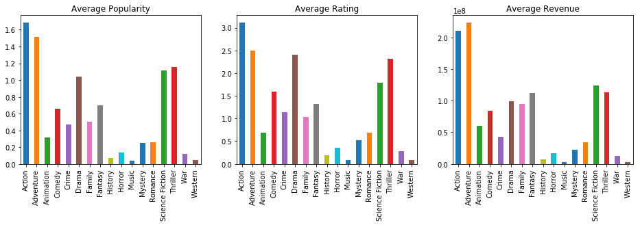

```python
# calculate the average values for each genre
genre_popularity = indicator_genres.multiply(genres_lookup.popularity, axis=0).mean();
genre_rating = indicator_genres.multiply(genres_lookup.vote_average, axis=0).mean();
genre_revenue = indicator_genres.multiply(genres_lookup.revenue_adj, axis=0).mean();

fig, axes = plt.subplots(ncols=3, figsize=(16, 4));
genre_popularity.plot(kind='bar', ax=axes[0], title='Average Popularity');
genre_rating.plot(kind='bar', ax=axes[1], title='Average Rating');
genre_revenue.plot(kind='bar', ax=axes[2], title='Average Revenue');
```

**Conclusion 4-1:** Look at the dataset as a whole, Action movies are most popular and with highest average rating and high average revenue. On the second rank are Adventure movies, Drama, Science Fiction and Thriller are also considerably more popular than other genres with higher ratings.

**Approach 2:** Organize the numbers of movies produced in all genre categories by year, the increase in production can give a hint about which genres are most popular in different time intervals.

```python
# divide the genres look up table in different time periods
genres_lookup['intervals'] = pd.cut(genres_lookup.release_year, bins=[1959, 1969, 1979, 1989, 1999, 2009, 2019])
genres_lookup.head(1)
```

|  | id | popularity | vote_average | revenue_adj | release_year | director | genres | Action | Adventure | Animation | ... | History | Horror | Music | Mystery | Romance | Science Fiction | Thriller | War | Western | intervals |
| --- | --- | --- | --- | --- | --- | --- | --- | --- | --- | --- | --- | --- | --- | --- | --- | --- | --- | --- | --- | --- | --- |
| 0 | 135397 | 32.985763 | 6.5 | 1.392446e+09 | 2015 | Colin Trevorrow | Action\|Adventure\|Science Fiction\|Thriller | 1.0 | 1.0 | 0.0 | ... | 0.0 | 0.0 | 0.0 | 0.0 | 0.0 | 1.0 | 1.0 | 0.0 | 0.0 | (2009, 2019] |

1 rows × 25 columns

```python
# group the genres by time intervals and count the total number of each genre in each time intervals
genres_by_year = genres_lookup.groupby('intervals').sum()
genres_by_year.drop(['id','popularity','vote_average','revenue_adj','release_year'], axis=1, inplace=True)
genres_by_year.head(1)
```

| intervals | Action | Adventure | Animation | Comedy | Crime | Drama | Family | Fantasy | History | Horror | Music | Mystery | Romance | Science Fiction | Thriller | War | Western |
| --- | --- | --- | --- | --- | --- | --- | --- | --- | --- | --- | --- | --- | --- | --- | --- | --- | --- |
| (1959, 1969] | 0.0 | 1.0 | 0.0 | 0.0 | 0.0 | 1.0 | 0.0 | 0.0 | 0.0 | 1.0 | 0.0 | 1.0 | 0.0 | 1.0 | 1.0 | 0.0 | 0.0 |

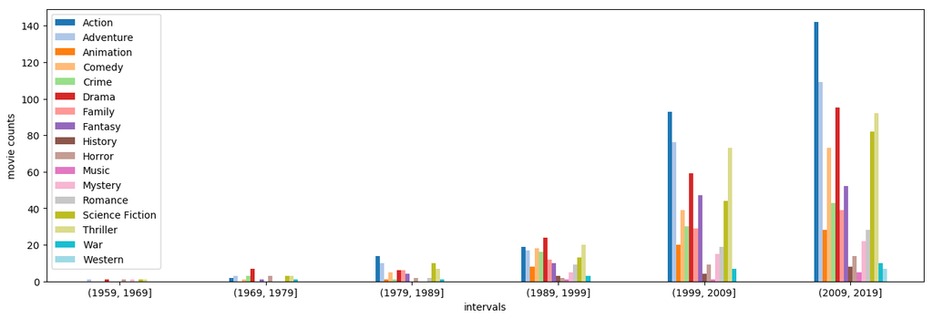

```python
# set up the bar plot and display the changes in movie production over years
mpl.style.use('default')
fig, axis = plt.subplots(figsize=(16, 5));
genres_by_year.plot(kind='bar', ax=axis, cmap="tab20");
plt.xticks(rotation='horizontal');
plt.ylabel('movie counts');
```

**Q5: Do comercially successful movies always have higher ratings?**

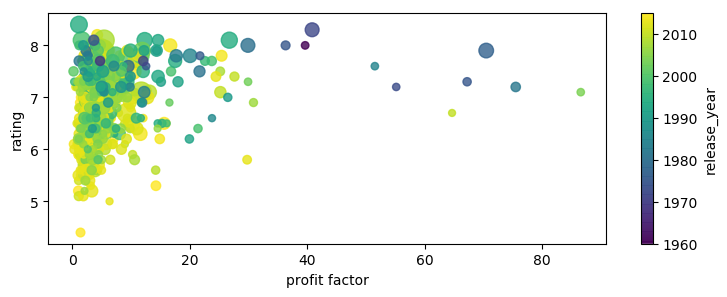

```python
fig, axis = plt.subplots(figsize=(9,3))

df2.plot.scatter('profit_factor', 'vote_average', c='release_year', ax=axis, s=df2.vote_count/40, alpha=0.8, colormap='viridis');
axis.set_ylabel('rating');
axis.set_xlabel('profit factor');
```

**Conclusion 5:** The movies with higher financial performance have also higher ratings, but movies with higher ratings not always are commercially successful.

**Q6: What kinds of properties are associated with movies that have high revenues?**  
Possible affecting factors or properties include: 1. the distribution of movies, for example in which season the movie is released, 2. the influence or reputation of director/cast, resources that the production company has, 3. runtime, budget/investment, viewers' rating, popularity may also have correlation to revenue, which will be investigated here.

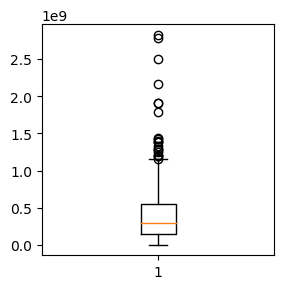

```python
# take a look of the distribution of revenues
fig, axis = plt.subplots(figsize=(3,3))
axis.boxplot(df2.revenue_adj);
```

```python
# choose the movies with revenue abover average as subjects of investigation
df4 = df2.query('revenue_adj >= revenue_adj.mean()')
df4.set_index(np.arange(df4.shape[0]), inplace=True)
df4.head(1)
```

|  | id | popularity | budget | revenue | original_title | cast | director | runtime | genres | production_companies | release_date | vote_count | vote_average | release_year | budget_adj | revenue_adj | profit_factor |
| --- | --- | --- | --- | --- | --- | --- | --- | --- | --- | --- | --- | --- | --- | --- | --- | --- | --- |
| 0 | 135397 | 32.985763 | 150000000 | 1513528810 | Jurassic World | Chris Pratt\|Bryce Dallas Howard\|Irrfan Khan\|Vi... | Colin Trevorrow | 124 | Action\|Adventure\|Science Fiction\|Thriller | Universal Studios\|Amblin Entertainment\|Legenda... | 2015-09-06 | 5562 | 6.5 | 2015 | 1.379999e+08 | 1.392446e+09 | 10.090192 |

**1-Correlation between movie distribution and revenue**

```python
# based on the release date, the season information can be derived
# then group the data by season and calculate the mean revenue, then save as a new data frame
df4['season'] = df4.release_date.apply(lambda dt: (dt.month%12 + 3)//3)
revenue_by_season = df4.groupby('season').revenue_adj.apply(np.mean)
```

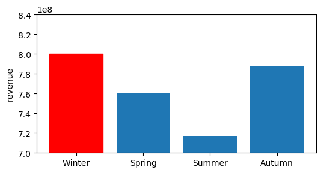

```python
# plot the average revenue from different seasons
fig, ax=plt.subplots(figsize=(6,3))

p = plt.bar(['Winter', 'Spring', 'Summer', 'Autumn'], revenue_by_season);
p[0].set_color('r');
ax.set_ylabel('revenue');
ax.set_ylim([7e8, 8.4e8]);
```

**Conclusion 6-1:** Movies distributed in winter have the highest average revenue.

**2-Correlation between movie popularity/runtime/vote average/budget and revenue**

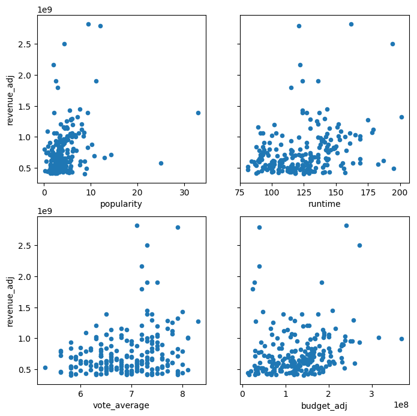

```python
fig, axes = plt.subplots(nrows = 2, ncols = 2, figsize=(8,8), sharey=True)

df4.plot.scatter('popularity', 'revenue_adj', ax=axes[0,0]);
df4.plot.scatter('runtime', 'revenue_adj', ax=axes[0,1]);
df4.plot.scatter('vote_average', 'revenue_adj', ax=axes[1,0]);
df4.plot.scatter('budget_adj', 'revenue_adj', ax=axes[1,1]);
```

**Conclusion 6-2:** The correlations between popularity/runtime/vote average/budget and movie revenue seem to be weak.

**3-Correlation between Director/Cast/Production Company and rating/revenue**  
The investigation is conducted using similar approach to the investigation on which genres are popular.

```python
# group df4 by director, and calculate the mean revenue/rating of movies directed by each director
# the movie counts of a director is used as an indicator for the influence and resource that director may have
director_revenue = df4.groupby('director').revenue_adj.mean()
director_movie_counts = df4.groupby('director').count()['id']
director_movie_rating = df4.groupby('director').vote_average.mean()
```

```python
director_df = pd.DataFrame({'company': director_movie_counts.index,
                                        'movie_counts': director_movie_counts,
                                        'revenue': director_revenue,
                                        'movie_rating': director_movie_rating})
director_df.set_index(np.arange(director_df.shape[0]), inplace=True)
director_df.head()
```

|  | company | movie_counts | revenue | movie_rating |
| --- | --- | --- | --- | --- |
| 0 | Alan Taylor | 2 | 4.272156e+08 | 6.3 |
| 1 | Alejandro González Iñárritu | 1 | 4.903142e+08 | 7.2 |
| 2 | Alfonso Cuarón | 2 | 7.911768e+08 | 7.4 |
| 3 | Andrew Adamson | 1 | 8.360904e+08 | 6.5 |
| 4 | Andrew Adamson\|Kelly Asbury\|Conrad Vernon | 1 | 1.061904e+09 | 6.5 |

```python
# generate indicator matrix for the cast column and combine with other information to generate a look up table for cast
indicator_casts = indicator_matrix(df4, df4.cast)
cast_lookup = df4.join(indicator_casts)
cast_lookup.drop(['genres','production_companies'], axis=1, inplace=True)
cast_lookup.head(1)
```

|  | id | popularity | budget | revenue | original_title | cast | director | runtime | release_date | vote_count | ... | William Moseley | William Redfield | Willow Smith | Woody Harrelson | Yeardley Smith | Zach Braff | Zach Galifianakis | Zachary Levi | Zachary Quinto | Zoe Saldana |
| --- | --- | --- | --- | --- | --- | --- | --- | --- | --- | --- | --- | --- | --- | --- | --- | --- | --- | --- | --- | --- | --- |
| 0 | 135397 | 32.985763 | 150000000 | 1513528810 | Jurassic World | Chris Pratt\|Bryce Dallas Howard\|Irrfan Khan\|Vi... | Colin Trevorrow | 124 | 2015-09-06 | 5562 | ... | 0.0 | 0.0 | 0.0 | 0.0 | 0.0 | 0.0 | 0.0 | 0.0 | 0.0 | 0.0 |

1 rows × 668 columns

```python
# the movie counts of a actor is used as an indicator for the influence and resource that actor may have
# and calculate the mean revenue/rating of movies played by each actor
cast_movie_counts = indicator_casts.sum()
cast_revenue = indicator_casts.multiply(cast_lookup.revenue_adj, axis=0).apply(np.mean);
cast_movie_rating = indicator_casts.multiply(cast_lookup.vote_average, axis=0).mean();
```

```python
cast_df = pd.DataFrame({'company': cast_movie_counts.index,
                                    'movie_counts': cast_movie_counts,
                                    'revenue': cast_revenue,
                                    'movie_rating': cast_movie_rating})
cast_df.set_index(np.arange(cast_df.shape[0]), inplace=True)
cast_df.head()
```

|  | company | movie_counts | revenue | movie_rating |
| --- | --- | --- | --- | --- |
| 0 | Aaron Eckhart | 1.0 | 4.764005e+06 | 0.038028 |
| 1 | Aaron Taylor-Johnson | 1.0 | 2.287921e+06 | 0.029108 |
| 2 | Abigail Hargrove | 1.0 | 2.337293e+06 | 0.031455 |
| 3 | Adam Brody | 1.0 | 2.506803e+06 | 0.030516 |
| 4 | Adam Driver | 1.0 | 8.932972e+06 | 0.035211 |

```python
# generate indicator matrix for the production_companies column
# and combine it with other information to generate a look up table for production companies
indicator_prodcom = indicator_matrix(df4, df4.production_companies)
prodcom_lookup = df4.join(indicator_prodcom)
prodcom_lookup.drop(['genres','cast'], axis=1, inplace=True)
prodcom_lookup.head(1)
```

|  | id | popularity | budget | revenue | original_title | director | runtime | production_companies | release_date | vote_count | ... | Walt Disney Studios Motion Pictures | Warner Bros. | Warner Bros. Animation | Weed Road Pictures | Wigram Productions | WingNut Films | Working Title Films | Zanuck Company, The | Zanuck/Brown Productions | Zohar International |
| --- | --- | --- | --- | --- | --- | --- | --- | --- | --- | --- | --- | --- | --- | --- | --- | --- | --- | --- | --- | --- | --- |
| 0 | 135397 | 32.985763 | 150000000 | 1513528810 | Jurassic World | Colin Trevorrow | 124 | Universal Studios\|Amblin Entertainment\|Legenda... | 2015-09-06 | 5562 | ... | 0.0 | 0.0 | 0.0 | 0.0 | 0.0 | 0.0 | 0.0 | 0.0 | 0.0 | 0.0 |

1 rows × 256 columns

```python
# the movie counts of a production company is used as an indicator for the influence and resource that company may have
# and calculate the mean revenue/rating of movies produced by each company
prodcom_movie_counts = indicator_prodcom.sum()
prodcom_revenue = indicator_prodcom.multiply(prodcom_lookup.revenue_adj, axis=0).apply(np.mean);
prodcom_movie_rating = indicator_prodcom.multiply(prodcom_lookup.vote_average, axis=0).mean();
```

```python
prodcom_df = pd.DataFrame({'company': prodcom_movie_counts.index,
                                          'movie_counts': prodcom_movie_counts,
                                          'revenue': prodcom_revenue,
                                          'movie_rating': prodcom_movie_rating})
prodcom_df.set_index(np.arange(prodcom_df.shape[0]), inplace=True)
prodcom_df.head(1)
```

|  | company | movie_counts | revenue | movie_rating |
| --- | --- | --- | --- | --- |
| 0 | 1492 Pictures | 5.0 | 1.980450e+07 | 0.159155 |

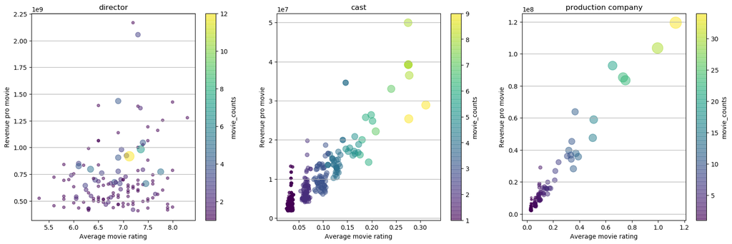

```python
# use scatter plot to show the correlation between director/cast/production company and the performance of their movies

fig, axes = plt.subplots(ncols=3, figsize=(20,6), sharex=False, sharey=False)
subtitles = ['director', 'cast', 'production company']

director_df.plot.scatter('movie_rating', 'revenue', c='movie_counts', ax=axes[0], s=director_df.movie_counts*20,  alpha=0.5, colormap='viridis');
cast_df.plot.scatter('movie_rating', 'revenue', c='movie_counts', ax=axes[1], s=cast_df.movie_counts*20,  alpha=0.5, colormap='viridis');
prodcom_df.plot.scatter('movie_rating', 'revenue', c='movie_counts', ax=axes[2], s=prodcom_df.movie_counts*10, alpha=0.5, colormap='viridis');

i = 0
for ax in axes:
    ax.yaxis.grid(True)
    ax.set_xlabel('Average movie rating');
    ax.set_ylabel('Revenue pro movie');
    ax.set_title(subtitles[i])
    i += 1
```

- The scatter plot show the influence of director, cast and production company on the revenue/rating of movies, the size and color of scatter points provide additional information about how many movies are directed/performed/produced by the corresponding director/actor/production company, which indicate also the influence on public to some extent.

**Conclusion 6-3:** The directors seem to have less influence on how the movie's performance is. However, on the other hand, the cast and movie performace is more strongly correlated, the correlation of movies with production companies seems to be strong too. Actors who have played in less movies may be less known by the public and less popular, they also seem to contribute less in the movie revenue and ratings, but the opposite can be also true that the actors are less known/popular because their played in less successful movies. This relationship can be used to explain the role production company in the performance of a movie, they are strongly positive correlated.

## Conclusions

**Reference**  
[1] [Cinematic Success Criteria and Their Predictors: The Art and Business of the Film Industry](https://onlinelibrary.wiley.com/doi/pdf/10.1002/mar.20280), Dean Keith Simonton, University of California, Davis.  
[2] Python for Data Analysis, Wes McKinney, O'REILLY.  
[3] [Pandas Documentation (Website)](http://pandas.pydata.org/pandas-docs/stable/)